# MACHINE LEARNING COURSE PROJECT

## ————————

Using devices such as Jawbone Up, Nike FuelBand, and Fitbit it is now possible to collect a large amount of data about personal activity relatively inexpensively. These type of devices are part of the quantified self movement – a group of enthusiasts who take measurements about themselves regularly to improve their health, to find patterns in their behavior, or because they are tech geeks. One thing that people regularly do is quantify how much of a particular activity they do, but they rarely quantify how well they do it. In this project, the goal will be to use data from accelerometers on the belt, forearm, arm, and dumbell of 6 participants. They were asked to perform barbell lifts correctly and incorrectly in 5 different ways. More information is available from the website here: http://groupware.les.inf.puc-rio.br/har (see the section on the Weight Lifting Exercise Dataset).

## The data: obtain and clean

## ——————————–

```r
library(knitr)
library(caret, quietly=TRUE)
library(kernlab)
library(corrplot)
library(tseries)
library(randomForest)
# download the file
#download.file("https://d396qusza40orc.cloudfront.net/predmachlearn/pml-training.csv",
              #destfile = '~yamina/Desktop/ShinyApp/', method="curl" )
#download.file("https://d396qusza40orc.cloudfront.net/predmachlearn/pml-testing.csv",
              #destfile =  '~yamina/Desktop/ShinyApp/', method="curl")

data_training <- read.csv('pml-training.csv',na.strings= c("NA",""," "))
str(data_training)
```

```
## 'data.frame':    19622 obs. of  160 variables:
##  $ X                       : int  1 2 3 4 5 6 7 8 9 10 ...
##  $ user_name               : Factor w/ 6 levels "adelmo","carlitos",..: 2 2 2 2 2 2 2 2 2 2 ...
##  $ raw_timestamp_part_1    : int  1323084231 1323084231 1323084231 1323084232 1323084232 1323084232 1323084232 1323084232 1323084232 1323084232 ...
##  $ raw_timestamp_part_2    : int  788290 808298 820366 120339 196328 304277 368296 440390 484323 484434 ...
##  $ cvtd_timestamp          : Factor w/ 20 levels "02/12/2011 13:32",..: 9 9 9 9 9 9 9 9 9 9 ...
##  $ new_window              : Factor w/ 2 levels "no","yes": 1 1 1 1 1 1 1 1 1 1 ...
##  $ num_window              : int  11 11 11 12 12 12 12 12 12 12 ...
##  $ roll_belt               : num  1.41 1.41 1.42 1.48 1.48 1.45 1.42 1.42 1.43 1.45 ...
##  $ pitch_belt              : num  8.07 8.07 8.07 8.05 8.07 8.06 8.09 8.13 8.16 8.17 ...
##  $ yaw_belt                : num  -94.4 -94.4 -94.4 -94.4 -94.4 -94.4 -94.4 -94.4 -94.4 -94.4 ...
##  $ total_accel_belt        : int  3 3 3 3 3 3 3 3 3 3 ...
##  $ kurtosis_roll_belt      : Factor w/ 396 levels "-0.016850","-0.021024",..: NA NA NA NA NA NA NA NA NA NA ...
##  $ kurtosis_picth_belt     : Factor w/ 316 levels "-0.021887","-0.060755",..: NA NA NA NA NA NA NA NA NA NA ...
##  $ kurtosis_yaw_belt       : Factor w/ 1 level "#DIV/0!": NA NA NA NA NA NA NA NA NA NA ...
```

[output cut: 86 more lines]

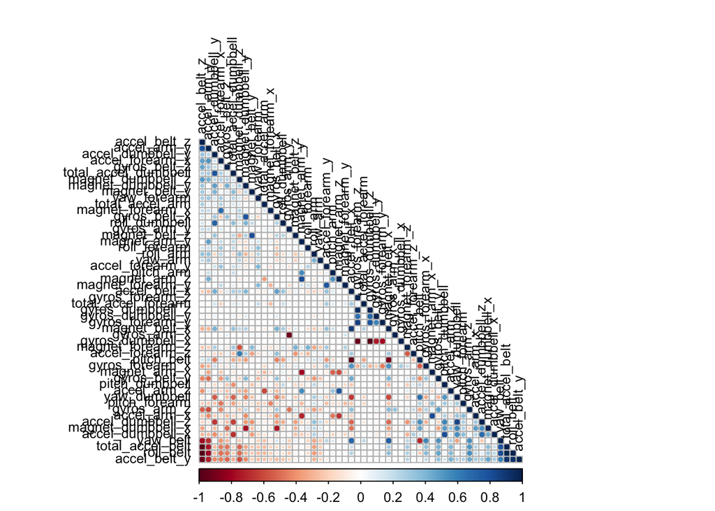

```r
#head(data_training)

# clean the data
data_training1 <- apply(data_training, 2, function(x) {sum(is.na(x))})
data_training2 <- data_training[,which(data_training1 == 0)]
data_training2 <- data_training2[8:length(data_training2)]

# split the data
inTrain <- createDataPartition(y = data_training2$classe, p = 0.7, list = FALSE)
training <- data_training2[inTrain, ]
crossval <- data_training2[-inTrain, ]
correlMatrix <- cor(training[, -length(training)])
corrplot(correlMatrix, order = "FPC", method = "circle", type = "lower", tl.cex = 0.8,  tl.col = rgb(0, 0, 0))
```

## Fitting a Random Forest Model

## ———————————-

A random forest model was selected to predict the classification and a correllation plot was produced to observe how strong the variables are correlated with each other.

```r
rmf <- randomForest(classe ~ ., data = training)
rmf
```

```
##
## Call:
##  randomForest(formula = classe ~ ., data = training)
##                Type of random forest: classification
##                      Number of trees: 500
## No. of variables tried at each split: 7
##
##         OOB estimate of  error rate: 0.52%
## Confusion matrix:
##      A    B    C    D    E class.error
## A 3902    2    0    1    1 0.001024066
## B    9 2646    3    0    0 0.004514673
## C    0   13 2380    3    0 0.006677796
## D    0    0   27 2223    2 0.012877442
## E    0    0    2    8 2515 0.003960396
```

```r
confusionMatrix(crossval$classe, predict(rmf, crossval))
```

```
## Confusion Matrix and Statistics
##
##           Reference
## Prediction    A    B    C    D    E
##          A 1673    1    0    0    0
##          B    2 1135    2    0    0
##          C    0    6 1019    1    0
##          D    0    0   11  953    0
##          E    0    0    0    3 1079
##
## Overall Statistics
##
##                Accuracy : 0.9956
##                  95% CI : (0.9935, 0.9971)
##     No Information Rate : 0.2846
##     P-Value [Acc > NIR] : < 2.2e-16
##
##                   Kappa : 0.9944
##  Mcnemar's Test P-Value : NA
##
## Statistics by Class:
##
##                      Class: A Class: B Class: C Class: D Class: E
## Sensitivity            0.9988   0.9939   0.9874   0.9958   1.0000
## Specificity            0.9998   0.9992   0.9986   0.9978   0.9994
## Pos Pred Value         0.9994   0.9965   0.9932   0.9886   0.9972
## Neg Pred Value         0.9995   0.9985   0.9973   0.9992   1.0000
## Prevalence             0.2846   0.1941   0.1754   0.1626   0.1833
## Detection Rate         0.2843   0.1929   0.1732   0.1619   0.1833
## Detection Prevalence   0.2845   0.1935   0.1743   0.1638   0.1839
## Balanced Accuracy      0.9993   0.9965   0.9930   0.9968   0.9997
```

## —————————

The model listed above is used to predict the classifications of the 20 results of new data that was proceesed in the same way.

```r
data_pre <- read.csv("pml-testing.csv", na.strings= c("NA",""," "))
data_test1 <- apply(data_pre, 2, function(x) {sum(is.na(x))})
data_test2 <- data_pre[,which(data_test1 == 0)]
data_test2 <- data_test2[8:length(data_test2)]
preTest <- predict(rmf, data_test2)
preTest
```

```
##  1  2  3  4  5  6  7  8  9 10 11 12 13 14 15 16 17 18 19 20
##  B  A  B  A  A  E  D  B  A  A  B  C  B  A  E  E  A  B  B  B
## Levels: A B C D E
```

```r
str(preTest)
```

```
##  Factor w/ 5 levels "A","B","C","D",..: 2 1 2 1 1 5 4 2 1 1 ...
##  - attr(*, "names")= chr [1:20] "1" "2" "3" "4" ...
```